REPRODUCEABLE RESEARCH-ASSIGNMENT # 2

Title: The most harmful threat to human health are tornados, thunderstorm winds, flood and excessive heat whereas floods, hurricanes, tornados, storm surges and hail have the worst economic consequences.

1. Synopsis

In short, I analyzed the data of natural events from he U.S. National Oceanic and Atmospheric Administration’s (NOAA) storm database. After observing the data, I cleaned up certain event types by referring to the accompanying data description. I then aggregated the fatality, body injury, property damage, and crop damage (by using the aggregate function) according to different event types. For data-visulization purpose I have summarized the most harmful events to human health along with the events that strongly damage property and crops (using figures). To reiterate, tornado, thunderstrom wind, flood, excessive heat are the most harmful to human health. Flood, hurricane, tornado, storm surge and hail have the highest economic impact.

2. Data processing

This step involves analyzing how different types of natural events impact human health and property damage.

```r
data$EVTYPE = toupper(data$EVTYPE)
dim(data)
```

```
## [1] 902297     37
```

There are 902297 observations and 37 variables.

```r
str(data)
```

```
## 'data.frame':    902297 obs. of  37 variables:
##  $ STATE__   : num  1 1 1 1 1 1 1 1 1 1 ...
##  $ BGN_DATE  : Factor w/ 16335 levels "1/1/1966 0:00:00",..: 6523 6523 4242 11116 2224 2224 2260 383 3980 3980 ...
##  $ BGN_TIME  : Factor w/ 3608 levels "00:00:00 AM",..: 272 287 2705 1683 2584 3186 242 1683 3186 3186 ...
##  $ TIME_ZONE : Factor w/ 22 levels "ADT","AKS","AST",..: 7 7 7 7 7 7 7 7 7 7 ...
##  $ COUNTY    : num  97 3 57 89 43 77 9 123 125 57 ...
##  $ COUNTYNAME: Factor w/ 29601 levels "","5NM E OF MACKINAC BRIDGE TO PRESQUE ISLE LT MI",..: 13513 1873 4598 10592 4372 10094 1973 23873 24418 4598 ...
##  $ STATE     : Factor w/ 72 levels "AK","AL","AM",..: 2 2 2 2 2 2 2 2 2 2 ...
##  $ EVTYPE    : chr  "TORNADO" "TORNADO" "TORNADO" "TORNADO" ...
##  $ BGN_RANGE : num  0 0 0 0 0 0 0 0 0 0 ...
##  $ BGN_AZI   : Factor w/ 35 levels "","  N"," NW",..: 1 1 1 1 1 1 1 1 1 1 ...
##  $ BGN_LOCATI: Factor w/ 54429 levels ""," Christiansburg",..: 1 1 1 1 1 1 1 1 1 1 ...
##  $ END_DATE  : Factor w/ 6663 levels "","1/1/1993 0:00:00",..: 1 1 1 1 1 1 1 1 1 1 ...
##  $ END_TIME  : Factor w/ 3647 levels ""," 0900CST",..: 1 1 1 1 1 1 1 1 1 1 ...
##  $ COUNTY_END: num  0 0 0 0 0 0 0 0 0 0 ...
```

[output cut: 23 more lines]

```r
head(data)
```

```
##   STATE__           BGN_DATE BGN_TIME TIME_ZONE COUNTY COUNTYNAME STATE
## 1       1  4/18/1950 0:00:00     0130       CST     97     MOBILE    AL
## 2       1  4/18/1950 0:00:00     0145       CST      3    BALDWIN    AL
## 3       1  2/20/1951 0:00:00     1600       CST     57    FAYETTE    AL
## 4       1   6/8/1951 0:00:00     0900       CST     89    MADISON    AL
## 5       1 11/15/1951 0:00:00     1500       CST     43    CULLMAN    AL
## 6       1 11/15/1951 0:00:00     2000       CST     77 LAUDERDALE    AL
##    EVTYPE BGN_RANGE BGN_AZI BGN_LOCATI END_DATE END_TIME COUNTY_END
## 1 TORNADO         0                                               0
## 2 TORNADO         0                                               0
## 3 TORNADO         0                                               0
## 4 TORNADO         0                                               0
## 5 TORNADO         0                                               0
## 6 TORNADO         0                                               0
##   COUNTYENDN END_RANGE END_AZI END_LOCATI LENGTH WIDTH F MAG FATALITIES
```

[output cut: 20 more lines]

After loading the data, it is better to keep all of the events name in upper case. This is because there are several events which are represented by multiple names such as “TSTM WIND” & “TUNDERSTORM WIND”. Let’s change that as follows:

```r
data[data$EVTYPE == "TSTM WIND", ]$EVTYPE = "THUNDERSTORM WIND"
data[data$EVTYPE == "THUNDERSTORM WINDS", ]$EVTYPE = "THUNDERSTORM WIND"
data[data$EVTYPE == "RIVER FLOOD", ]$EVTYPE = "FLOOD"
data[data$EVTYPE == "HURRICANE/TYPHOON", ]$EVTYPE = "HURRICANE-TYPHOON"
data[data$EVTYPE == "HURRICANE", ]$EVTYPE = "HURRICANE-TYPHOON"
```

3. Results
1. The most harmful events to human health

The following shows the top 10 severe weather events that caused the most fatalities. Let’s look at the four types of damage: fatality (FATALITIES) , injury (INJURIES), property damage (PROPDMG) and crop damage (CROPDMG)

FATALATIES

```r
fatal <- aggregate(FATALITIES ~ EVTYPE, data = data, sum)
fatal1 <- fatal[fatal$FATALITIES > 0, ]
fatalorder <- fatal1[order(fatal1$FATALITIES, decreasing = TRUE), ]
head(fatalorder)
```

```
##                EVTYPE FATALITIES
## 755           TORNADO       5633
## 116    EXCESSIVE HEAT       1903
## 138       FLASH FLOOD        978
## 243              HEAT        937
## 417         LIGHTNING        816
## 683 THUNDERSTORM WIND        701
```

I meant to aggregate fatality data by event type and rank them in descending order. Here tornado and excessive heat are two events which caused the most fatalities since 1950.

INJURIES

```r
injury <- aggregate(INJURIES ~ EVTYPE, data = data, sum)
injury1 <- injury[injury$INJURIES > 0, ]
injuryorder <- injury1[order(injury1$INJURIES, decreasing = TRUE), ]
head(injuryorder)
```

```
##                EVTYPE INJURIES
## 755           TORNADO    91346
## 683 THUNDERSTORM WIND     9353
## 154             FLOOD     6791
## 116    EXCESSIVE HEAT     6525
## 417         LIGHTNING     5230
## 243              HEAT     2100
```

Tornados are also implicated in high injury rate (below) follwed by thunderstorm wind.

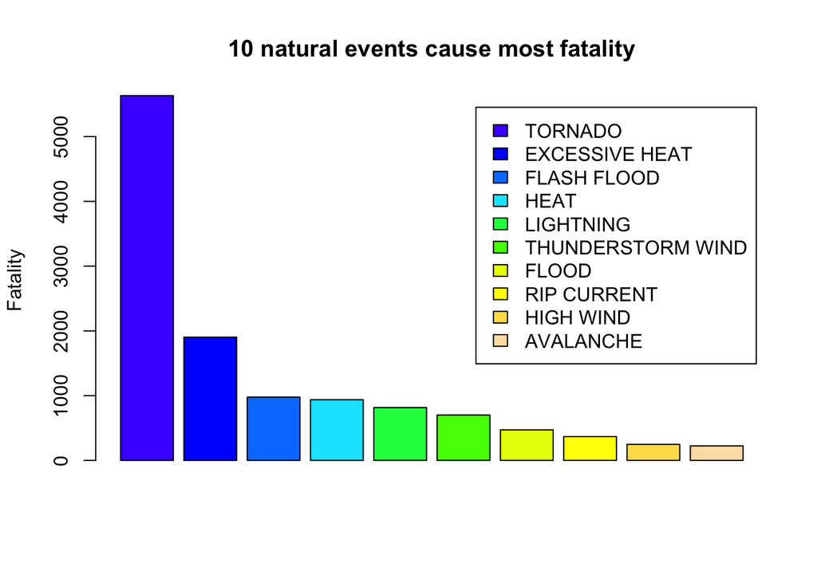

```r
par(mai=c(1.02,0.82,0.82,0.42))
barplot(fatalorder[1:10, 2], col = topo.colors(10), legend.text = fatalorder[1:10, 1], ylab = "Fatality", main = "10 natural events cause most fatality")
```

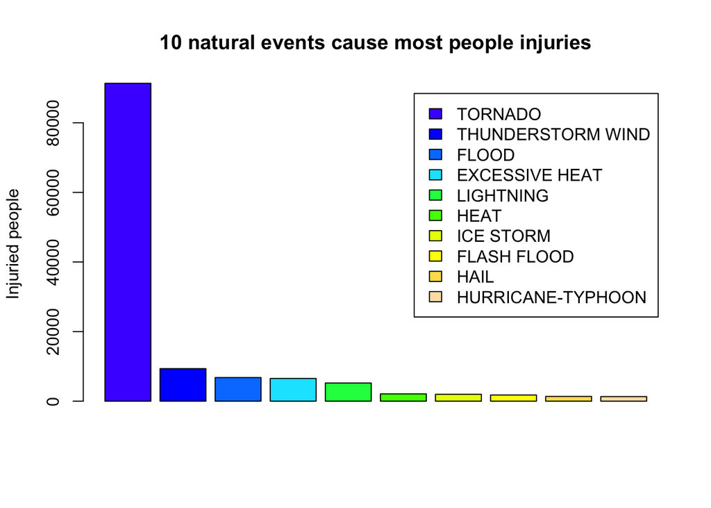

```r
par(mai=c(1.02,0.82,0.82,0.42))
barplot(injuryorder[1:10, 2], col = topo.colors(10), legend.text = injuryorder[1:10, 1], ylab = "Injuried people", main = "10 natural events cause most people injuries")
```

```r
intersect(fatalorder[1:10, 1], injuryorder[1:10, 1])
```

```
## [1] "TORNADO"           "EXCESSIVE HEAT"    "FLASH FLOOD"
## [4] "HEAT"              "LIGHTNING"         "THUNDERSTORM WIND"
## [7] "FLOOD"
```

There are 7 types of events which are listed in top 10 of fatality and body injury. Definitely, tornado is the most harmful event to human health while others uinclude excceise heat, flash flood, and thunderstorm wind.

2. The most harmful events to property

Here the goal was to summarize property and crop damage caused by the aforementioned natural events. The economic impact is measured by property and crop damages. PROPDMGEXP and CROPDMGEXP are factor variables with the following levels.

```r
unique(data$PROPDMGEXP)
```

```
##  [1] K M   B m + 0 5 6 ? 4 2 3 h 7 H - 1 8
## Levels:  - ? + 0 1 2 3 4 5 6 7 8 B h H K m M
```

```r
unique(data$CROPDMGEXP)
```

```
## [1]   M K m B ? 0 k 2
## Levels:  ? 0 2 B k K m M
```

According to the documentation, “K” represents thousands, “M” - millions and “B” - billions. To maintain uniformity, it is necessary to transform the exponential terms appropriately.

```r
data[data$PROPDMGEXP == "K", ]$PROPDMG <- data[data$PROPDMGEXP == "K", ]$PROPDMG * 1000
data[data$PROPDMGEXP == "M", ]$PROPDMG <- data[data$PROPDMGEXP == "M", ]$PROPDMG * 1e+06
data[data$PROPDMGEXP == "m", ]$PROPDMG <- data[data$PROPDMGEXP == "m", ]$PROPDMG * 1e+06
data[data$PROPDMGEXP == "B", ]$PROPDMG <- data[data$PROPDMGEXP == "B", ]$PROPDMG * 1e+09
data[data$CROPDMGEXP == "K", ]$CROPDMG <- data[data$CROPDMGEXP == "K", ]$CROPDMG * 1000
data[data$CROPDMGEXP == "k", ]$CROPDMG <- data[data$CROPDMGEXP == "k", ]$CROPDMG * 1000
data[data$CROPDMGEXP == "M", ]$CROPDMG <- data[data$CROPDMGEXP == "M", ]$CROPDMG * 1e+06
data[data$CROPDMGEXP == "m", ]$CROPDMG <- data[data$CROPDMGEXP == "m", ]$CROPDMG * 1e+06
data[data$CROPDMGEXP == "B", ]$CROPDMG <- data[data$CROPDMGEXP == "B", ]$CROPDMG * 1e+09
```

The next step is to aggregate propery and crop damage by event types and rank them in descending order.

```r
damage <- aggregate(PROPDMG ~ EVTYPE, data = data, sum)
damage1 <- damage[damage$PROPDMG > 0, ]
damageorder <- damage1[order(damage1$PROPDMG, decreasing = TRUE), ]
head(damageorder)
```

```
##                EVTYPE      PROPDMG
## 154             FLOOD 149776655307
## 371 HURRICANE-TYPHOON  81174159010
## 755           TORNADO  56937160779
## 597       STORM SURGE  43323536000
## 138       FLASH FLOOD  16140812067
## 212              HAIL  15732267048
```

The data shows that flood is the most harmful to property damage followed by hurricane-typhoon.

```r
cropdmg <- aggregate(CROPDMG ~ EVTYPE, data = data, sum)
cropdmg1 <- cropdmg[cropdmg$CROPDMG > 0, ]
cropdmgorder <- cropdmg1[order(cropdmg1$CROPDMG, decreasing = TRUE), ]
head(cropdmgorder)
```

```
##                EVTYPE     CROPDMG
## 84            DROUGHT 13972566000
## 154             FLOOD 10691427450
## 371 HURRICANE-TYPHOON  5349782800
## 386         ICE STORM  5022113500
## 212              HAIL  3025954473
## 138       FLASH FLOOD  1421317100
```

The differences between the 2 types of dammage are clear. This warrants adding the two types of damage together to estimate their sum.

```r
totaldmg <- merge(damageorder, cropdmgorder, by = "EVTYPE")
totaldmg$total = totaldmg$PROPDMG + totaldmg$CROPDMG
totaldmgorder <- totaldmg[order(totaldmg$total, decreasing = TRUE), ]
totaldmgorder[1:10, ]
```

```
##               EVTYPE      PROPDMG     CROPDMG        total
## 19             FLOOD 149776655307 10691427450 160468082757
## 52 HURRICANE-TYPHOON  81174159010  5349782800  86523941810
## 82           TORNADO  56937160779   414953270  57352114049
## 66       STORM SURGE  43323536000        5000  43323541000
## 31              HAIL  15732267048  3025954473  18758221521
## 15       FLASH FLOOD  16140812067  1421317100  17562129167
## 6            DROUGHT   1046106000 13972566000  15018672000
## 73 THUNDERSTORM WIND   9704038802  1159505188  10863543990
## 54         ICE STORM   3944927860  5022113500   8967041360
## 85    TROPICAL STORM   7703890550   678346000   8382236550
```

We can see the top 10 events that cause most economic consequences are flood, hurricane, tornado, storm surge and hail.

[figure not shown]

```r
par(mai=c(1.02,0.82,0.82,0.42))
barplot(totaldmgorder[1:10, 2], col = heat.colors(10), legend.text = totaldmgorder[1:10, 1], ylab = "Total Crop Damage ($)", main = "Top 10 Events Causing Most Total Damage")
```